## Task 2. Exploraring a dataset

For this task you have to use dataset from file `airquality.csv`. The description of the data you can find by the [link](https://www.rdocumentation.org/packages/datasets/versions/3.6.2/topics/airquality).

Example, how to work with the dataset. For instanse, we want to find month (column `Month`) with highest mean temperature (`Temp`)

```r
library(dplyr)
airquality |>
  group_by(Month) |>
  summarise(mean_temp = mean(Temp)) |>
  filter(mean_temp == max(mean_temp))
```

```
## # A tibble: 1 × 2
##   Month mean_temp
##   <int>     <dbl>
## 1     8      84.0
```

You task is to answer the following questions about this data by writing appropriate code.

1. What are the column names of the data frame?

```r
names(airquality)
```

```
## [1] "Ozone"   "Solar.R" "Wind"    "Temp"    "Month"   "Day"
```

2. What are the row names of the data frame?

```r
row.names(airquality)
```

```
##   [1] "1"   "2"   "3"   "4"   "5"   "6"   "7"   "8"   "9"   "10"  "11"  "12"
##  [13] "13"  "14"  "15"  "16"  "17"  "18"  "19"  "20"  "21"  "22"  "23"  "24"
##  [25] "25"  "26"  "27"  "28"  "29"  "30"  "31"  "32"  "33"  "34"  "35"  "36"
##  [37] "37"  "38"  "39"  "40"  "41"  "42"  "43"  "44"  "45"  "46"  "47"  "48"
##  [49] "49"  "50"  "51"  "52"  "53"  "54"  "55"  "56"  "57"  "58"  "59"  "60"
##  [61] "61"  "62"  "63"  "64"  "65"  "66"  "67"  "68"  "69"  "70"  "71"  "72"
##  [73] "73"  "74"  "75"  "76"  "77"  "78"  "79"  "80"  "81"  "82"  "83"  "84"
##  [85] "85"  "86"  "87"  "88"  "89"  "90"  "91"  "92"  "93"  "94"  "95"  "96"
##  [97] "97"  "98"  "99"  "100" "101" "102" "103" "104" "105" "106" "107" "108"
## [109] "109" "110" "111" "112" "113" "114" "115" "116" "117" "118" "119" "120"
## [121] "121" "122" "123" "124" "125" "126" "127" "128" "129" "130" "131" "132"
## [133] "133" "134" "135" "136" "137" "138" "139" "140" "141" "142" "143" "144"
## [145] "145" "146" "147" "148" "149" "150" "151" "152" "153"
```

3. Extract the first 6 rows of the data frame and print them to the console

```r
head(airquality)
```

```
##   Ozone Solar.R Wind Temp Month Day
## 1    41     190  7.4   67     5   1
## 2    36     118  8.0   72     5   2
## 3    12     149 12.6   74     5   3
## 4    18     313 11.5   62     5   4
## 5    NA      NA 14.3   56     5   5
## 6    28      NA 14.9   66     5   6
```

4. How many observations (i.e. rows) are in this data frame?

```r
nrow(airquality)
```

```
## [1] 153
```

5. Extract the last 6 rows of the data frame and print them to the console

```r
tail(airquality)
```

```
##     Ozone Solar.R Wind Temp Month Day
## 148    14      20 16.6   63     9  25
## 149    30     193  6.9   70     9  26
## 150    NA     145 13.2   77     9  27
## 151    14     191 14.3   75     9  28
## 152    18     131  8.0   76     9  29
## 153    20     223 11.5   68     9  30
```

6. How many missing values are in the “Ozone” column of this data frame?

```r
sum(is.na(airquality$Ozone))
```

```
## [1] 37
```

7. What is the mean of the “Ozone” column in this dataset? Exclude missing values (coded as NA) from this calculation.

```r
mean(airquality$Ozone, na.rm = TRUE)
```

```
## [1] 42.12931
```

8. Extract the subset of rows of the data frame where Ozone values are above 31 and Temp values are above 90.

```r
#with(airquality, subset(Ozone > 31, Temp > 90))
#subset(airquality, Ozone > 31 & Temp > 90)
airquality %>%
  filter(Ozone > 31, Temp > 90)
```

```
##    Ozone Solar.R Wind Temp Month Day
## 1     97     267  6.3   92     7   8
## 2     97     272  5.7   92     7   9
## 3     76     203  9.7   97     8  28
## 4    118     225  2.3   94     8  29
## 5     84     237  6.3   96     8  30
## 6     85     188  6.3   94     8  31
## 7     96     167  6.9   91     9   1
## 8     78     197  5.1   92     9   2
## 9     73     183  2.8   93     9   3
## 10    91     189  4.6   93     9   4
```

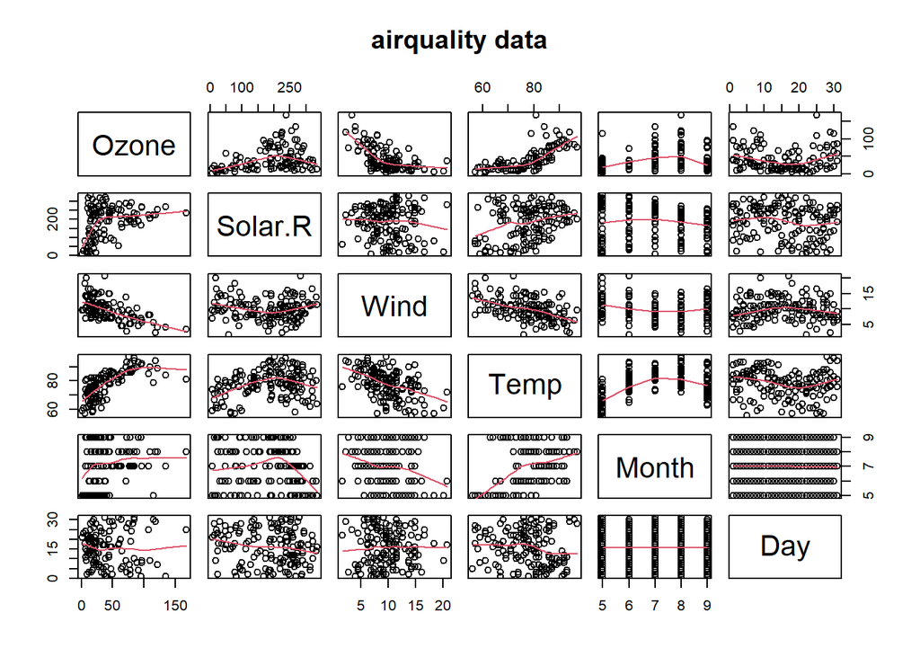

```r
require(graphics)
pairs(airquality, panel = panel.smooth, main = "airquality data")
```